# Ford Gobike Trip data Exploration

## Introduction

- This dataset contains 183412 entries of bike rides and 16 columns with various information about each bike ride trip.
- The data row entry describes the duration of each bike ride trip in seconds, detailing the start time and the end time of the trip.
- The data also has the start_station_id and end_station_id which uniquely identify the locations in which the users started and ended their bike rides.
- There are also attached coordinates in terms of longitudes and latitudes of these unique locations
- Each entry also has the unique identification of the bike used, the user type and their gender together with the year the user was born.

## Preliminary wrangling

```python
# Import the required packages
import pandas as pd
import numpy as np
import matplotlib.pyplot as plt
import seaborn as sns
import os

%matplotlib inline
```

```python
# Change the directory
os.chdir('D:/Learning/Data Science/UDACITY/DATA VISUALIZATION/Project')
print(os.getcwd())
```

```
D:\Learning\Data Science\UDACITY\DATA VISUALIZATION\Project
```

```python
# load in the dataset into a pandas dataframe
go_bike = pd.read_csv('201902-fordgobike-tripdata.csv')
go_bike.head(4)
```

|  | duration_sec | start_time | end_time | start_station_id | start_station_name | start_station_latitude | start_station_longitude | end_station_id | end_station_name | end_station_latitude | end_station_longitude | bike_id | user_type | member_birth_year | member_gender | bike_share_for_all_trip |
| --- | --- | --- | --- | --- | --- | --- | --- | --- | --- | --- | --- | --- | --- | --- | --- | --- |
| 0 | 52185 | 2019-02-28 17:32:10.1450 | 2019-03-01 08:01:55.9750 | 21.0 | Montgomery St BART Station (Market St at 2nd St) | 37.789625 | -122.400811 | 13.0 | Commercial St at Montgomery St | 37.794231 | -122.402923 | 4902 | Customer | 1984.0 | Male | No |
| 1 | 42521 | 2019-02-28 18:53:21.7890 | 2019-03-01 06:42:03.0560 | 23.0 | The Embarcadero at Steuart St | 37.791464 | -122.391034 | 81.0 | Berry St at 4th St | 37.775880 | -122.393170 | 2535 | Customer | NaN | NaN | No |
| 2 | 61854 | 2019-02-28 12:13:13.2180 | 2019-03-01 05:24:08.1460 | 86.0 | Market St at Dolores St | 37.769305 | -122.426826 | 3.0 | Powell St BART Station (Market St at 4th St) | 37.786375 | -122.404904 | 5905 | Customer | 1972.0 | Male | No |
| 3 | 36490 | 2019-02-28 17:54:26.0100 | 2019-03-01 04:02:36.8420 | 375.0 | Grove St at Masonic Ave | 37.774836 | -122.446546 | 70.0 | Central Ave at Fell St | 37.773311 | -122.444293 | 6638 | Subscriber | 1989.0 | Other | No |

```python
# check the shape - no of rows and columns
go_bike.shape
```

```
(183412, 16)
```

```python
# get the data types and general information
go_bike.info()
```

```
<class 'pandas.core.frame.DataFrame'>
RangeIndex: 183412 entries, 0 to 183411
Data columns (total 16 columns):
 #   Column                   Non-Null Count   Dtype
---  ------                   --------------   -----
 0   duration_sec             183412 non-null  int64
 1   start_time               183412 non-null  object
 2   end_time                 183412 non-null  object
 3   start_station_id         183215 non-null  float64
 4   start_station_name       183215 non-null  object
 5   start_station_latitude   183412 non-null  float64
 6   start_station_longitude  183412 non-null  float64
 7   end_station_id           183215 non-null  float64
 8   end_station_name         183215 non-null  object
 9   end_station_latitude     183412 non-null  float64
 10  end_station_longitude    183412 non-null  float64
 11  bike_id                  183412 non-null  int64
 12  user_type                183412 non-null  object
 13  member_birth_year        175147 non-null  float64
 14  member_gender            175147 non-null  object
 15  bike_share_for_all_trip  183412 non-null  object
dtypes: float64(7), int64(2), object(7)
memory usage: 22.4+ MB
```

```python
# get the summary statistics
go_bike.describe()
```

|  | duration_sec | start_station_id | start_station_latitude | start_station_longitude | end_station_id | end_station_latitude | end_station_longitude | bike_id | member_birth_year |
| --- | --- | --- | --- | --- | --- | --- | --- | --- | --- |
| count | 183412.000000 | 183215.000000 | 183412.000000 | 183412.000000 | 183215.000000 | 183412.000000 | 183412.000000 | 183412.000000 | 175147.000000 |
| mean | 726.078435 | 138.590427 | 37.771223 | -122.352664 | 136.249123 | 37.771427 | -122.352250 | 4472.906375 | 1984.806437 |
| std | 1794.389780 | 111.778864 | 0.099581 | 0.117097 | 111.515131 | 0.099490 | 0.116673 | 1664.383394 | 10.116689 |
| min | 61.000000 | 3.000000 | 37.317298 | -122.453704 | 3.000000 | 37.317298 | -122.453704 | 11.000000 | 1878.000000 |
| 25% | 325.000000 | 47.000000 | 37.770083 | -122.412408 | 44.000000 | 37.770407 | -122.411726 | 3777.000000 | 1980.000000 |
| 50% | 514.000000 | 104.000000 | 37.780760 | -122.398285 | 100.000000 | 37.781010 | -122.398279 | 4958.000000 | 1987.000000 |
| 75% | 796.000000 | 239.000000 | 37.797280 | -122.286533 | 235.000000 | 37.797320 | -122.288045 | 5502.000000 | 1992.000000 |
| max | 85444.000000 | 398.000000 | 37.880222 | -121.874119 | 398.000000 | 37.880222 | -121.874119 | 6645.000000 | 2001.000000 |

```python
# remove this year data, seems unrealistic!
go_bike = go_bike[go_bike.member_birth_year !=1878]
```

```python
# check for nulls
go_bike.isnull().sum()
```

```
duration_sec                  0
start_time                    0
end_time                      0
start_station_id            197
start_station_name          197
start_station_latitude        0
start_station_longitude       0
end_station_id              197
end_station_name            197
end_station_latitude          0
end_station_longitude         0
bike_id                       0
user_type                     0
member_birth_year          8265
member_gender              8265
bike_share_for_all_trip       0
dtype: int64
```

- Some several rows have missing data, with most data missing in the member gender and birth_year.
- There is also exact missing data in the in the four rows: start station-id, start_stion_name, end_station_id, end_station_name.

```python
# check for duplicates
go_bike.duplicated().sum()
```

```
0
```

- There are no duplicated rows of data in this dataset

```python
# check for data types
go_bike.dtypes
```

```
duration_sec                 int64
start_time                  object
end_time                    object
start_station_id           float64
start_station_name          object
start_station_latitude     float64
start_station_longitude    float64
end_station_id             float64
end_station_name            object
end_station_latitude       float64
end_station_longitude      float64
bike_id                      int64
user_type                   object
member_birth_year          float64
member_gender               object
bike_share_for_all_trip     object
dtype: object
```

- Most of the data types are correct,
- We can change the following data types to the correct ones to enhance further analysis:
  - start_time: from object to datetime
  - end_time: from object to datetime
  - start_station_id: from float to string
  - end_station_id: from float to string
  - bike_id: from int64 to string

```python
# make a copy before cleaning
go_bike_copy = go_bike.copy()
```

```python
# change the data types
go_bike['start_time'] = pd.to_datetime(go_bike['start_time'])
go_bike['end_time'] = pd.to_datetime(go_bike['end_time'])
go_bike['start_station_id'] = go_bike['start_station_id'].astype('str')
go_bike['end_station_id'] = go_bike['end_station_id'].astype('str')
go_bike['bike_id'] = go_bike['bike_id'].astype('str')
```

```python
# fill the null values in the member_birth_year with average year
mean_year= go_bike['member_birth_year'].mean()
go_bike['member_birth_year'].fillna(mean_year, inplace = True)
```

```python
go_bike['member_birth_year'] = go_bike['member_birth_year'].astype('int64')
```

#### Main features

- There are a number of key features which can help derive insights onto the dataset.
- These include:
  - The start and end station IDs are import as they can give insights into which stations are preferred by users
  - The trip duration can also give insights into how long people get to ride the bikes, can be broken down gender-wise for further investigation.
  - Member birth year is also crucial to help analyze the ages of the bike users
  - The gender of the users can also be useful to our analysis
  - Age of the users

# Exploratory Data Visualization

```python
# get summary statistics of the duration column
go_bike['duration_sec'].describe()
```

```
count    183411.000000
mean        726.074358
std        1794.393822
min          61.000000
25%         325.000000
50%         514.000000
75%         796.000000
max       85444.000000
Name: duration_sec, dtype: float64
```

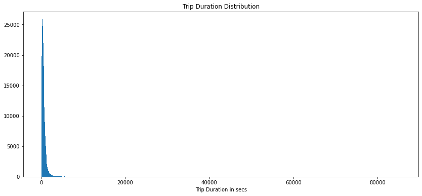

```python
# plot a histogram
plt.figure(figsize = (14,6))
bins = np.arange(50, go_bike['duration_sec'].max() + 100, 100)

plt.hist(data = go_bike, x = 'duration_sec', bins = bins)
plt.xlabel('Trip Duration in secs')
plt.title('Trip Duration Distribution')
plt.show()
```

- The histogram above shows that the data is concentrated in a small region ~ o to around 4000 seconds. Let me zoom in and limit the the x-axis to 2500.
- However, the data is concentrated up to the 2500 seconds duration
- The next slide I'll zoom in to see a clearer distribution

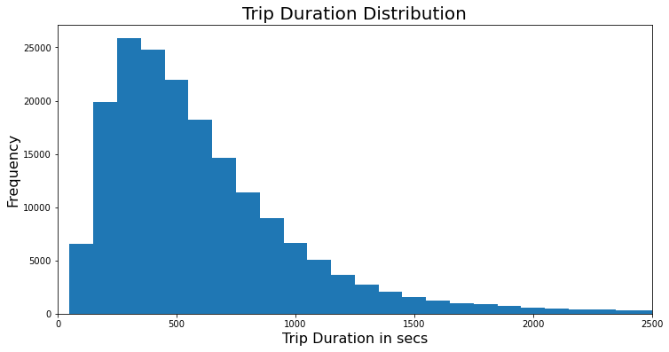

```python
# plot a histogram
import matplotlib.pyplot as plt
plt.figure(figsize = (12,6))
bins = np.arange(50, go_bike['duration_sec'].max() + 100, 100)

plt.hist(data = go_bike, x = 'duration_sec', bins = bins)
plt.xlim([0,2500])
plt.xlabel('Trip Duration in secs', fontsize = 16)
plt.ylabel('Frequency', fontsize = 16)
plt.title('Trip Duration Distribution', fontsize = 20)
plt.show();
```

- Zooming in to the 2500secs, the shape of the trip duration histogram seems to be right skewed.

```python
# number of unique bike stations
no_of_start_stations = go_bike['start_station_id'].nunique()
no_of_end_stations = go_bike['end_station_id'].nunique()
no_of_bikes = go_bike['bike_id'].nunique()
no_of_user_types = go_bike['user_type'].nunique()


print(f'{no_of_start_stations} start stations were used in the trips')
print(f'{no_of_end_stations} end stations were used in the trips')
print(f'{no_of_bikes} unique bikes were used in the trips')
print(f'There were {no_of_user_types} user types involved in the trips')
```

```
330 start stations were used in the trips
330 end stations were used in the trips
4646 unique bikes were used in the trips
There were 2 user types involved in the trips
```

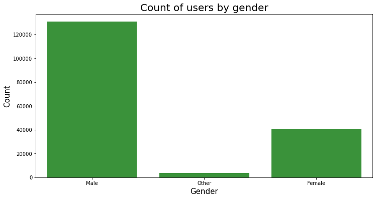

```python
# Explore the number of users by gender
plt.figure(figsize = (12,6))
base_color = sns.color_palette()[2]

sns.countplot(data = go_bike,
              x = 'member_gender',
              color = base_color);
plt.xlabel('Gender', fontsize = 15)
plt.ylabel('Count', fontsize = 15)
plt.title('Count of users by gender', fontsize = 20);
```

- The were many males in the bike users with the females following and the unidentified gender being last.

```python
usertype = pd.DataFrame(go_bike['user_type'].value_counts().reset_index())
usertype
```

|  | index | user_type |
| --- | --- | --- |
| 0 | Subscriber | 163544 |
| 1 | Customer | 19867 |

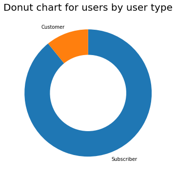

```python
# plot a pie chart
plt.figure(figsize = (12,6))
plt.pie(data = usertype,
        x = 'user_type',
        labels = 'index',
        startangle = 90,
        counterclock = False,
        wedgeprops = {'width' : 0.4})
plt.title('Donut chart for users by user type', fontsize = 20)
plt.show()
```

- The bike users recorded were predominantly subscribers with a few customers

```python
birth_years = pd.DataFrame(go_bike['member_birth_year'].value_counts().reset_index())

birth_years.sort_values(by = 'member_birth_year', ascending = True).head(5)
```

|  | index | member_birth_year |
| --- | --- | --- |
| 73 | 1927 | 1 |
| 70 | 1928 | 1 |
| 72 | 1910 | 1 |
| 71 | 1930 | 1 |
| 69 | 1934 | 2 |

```python
# Establish the unique number of birth years
unique_years = go_bike['member_birth_year'].nunique()
Earliest_year = go_bike['member_birth_year'].min()
latest_year = go_bike['member_birth_year'].max()

print(f'There are {unique_years} in the dataset')
print(f'The earliest birth year for the birth of the users was {Earliest_year}.')
print(f'The latest birth year for the birth of the users was {latest_year}.')
```

```
There are 74 in the dataset
The earliest birth year for the birth of the users was 1900.
The latest birth year for the birth of the users was 2001.
```

### Count by Age distibution

- The distribution shows that nost users were born in the year 1984, with most and high concentration between 1980 to 1996
- The histogram distribution of the memmber year of birth seems to left skewed.
- There is also an observation of the high concentration of members' births fron 1980 to just before 2000

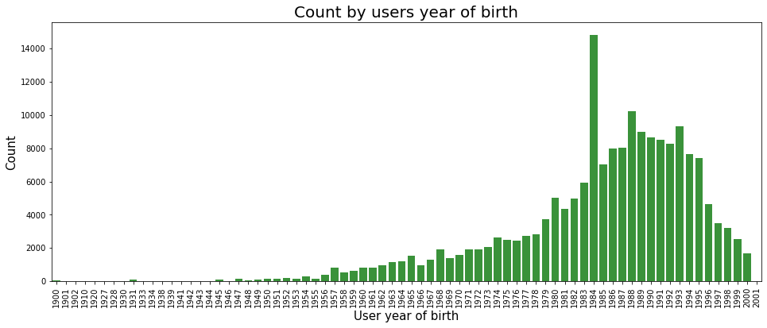

```python
plt.figure(figsize = (16,6))
sns.countplot(data = go_bike, x = 'member_birth_year', color = base_color);
plt.xticks(rotation = 90);
plt.xlabel('User year of birth', fontsize = 15)
plt.ylabel('Count', fontsize = 15)
plt.title('Count by users year of birth', fontsize = 20);
```

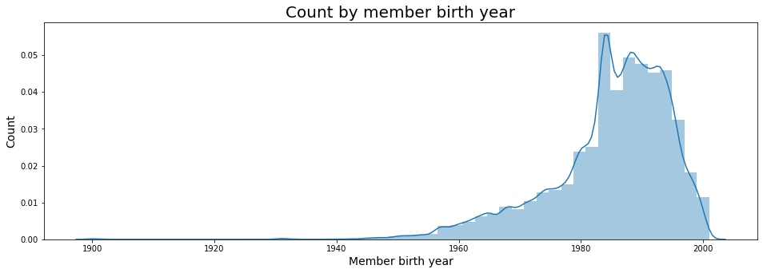

```python
plt.figure(figsize = (16,5))
sns.distplot(go_bike['member_birth_year'], color = sns.color_palette()[0])
plt.xlabel('Member birth year', fontsize=14)
plt.ylabel('Count', fontsize=14)
plt.title('Count by member birth year', fontsize=20);
```

Same distibution, better detail on the concentration of the year of birth as it shows more were born past 1980

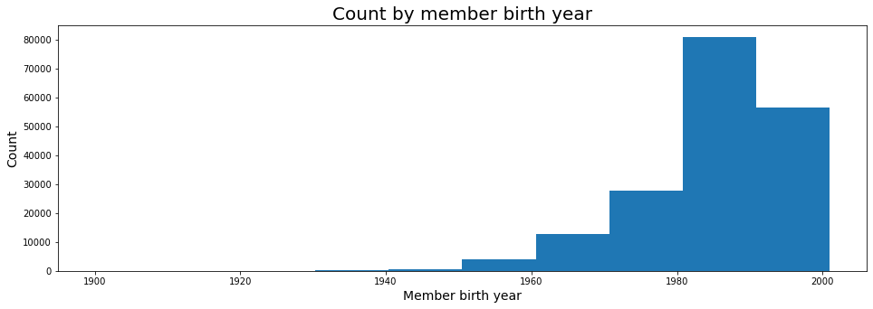

```python
plt.figure(figsize = (16,5))
plt.hist(data = go_bike, x = 'member_birth_year');
plt.xlabel('Member birth year', fontsize=14)
plt.ylabel('Count', fontsize=14)
plt.title('Count by member birth year', fontsize=20);
```

The distribution is left skewed, higher number of bike users born past 1980

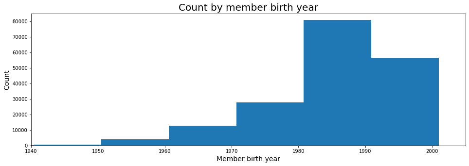

```python
plt.figure(figsize = (16,5))
plt.hist(data = go_bike, x = 'member_birth_year')
plt.xlim([1940, 2005]);
plt.xlabel('Member birth year', fontsize=14)
plt.ylabel('Count', fontsize=14)
plt.title('Count by member birth year', fontsize=20);
```

Zoomed in on the years with more bike users

# Bivariate Exploration

- In this section I am going to focus on the how two of the features(variables) of the data relate to each other - bivariate.
- In the dataset, the variables are of two types - numeric and categorical varibles.
- The numeric variables include:
  - duration_sec
  - birth year
  - distance covered - new column
  - average speed - new column

#### Distance covered between the stations

```python
## Create a distance covered column
## Will use theHaver Formula and and also use distancemetric & radians packages
# import the packages
from sklearn.neighbors import DistanceMetric
from math import radians

# define the haverseine_vectorize function to take the stand & end coordinates for the trips
def haversine_vectorize(start_station_longitude, start_station_latitude, end_station_longitude, end_station_latitude):
    start_station_longitude, start_station_latitude, end_station_longitude, end_station_latitude = map(np.radians, [start_station_longitude, start_station_latitude, end_station_longitude, end_station_latitude])

    # form the new longitudes from the the subtractions of the start and end
    newlon = end_station_longitude - start_station_longitude
    newlat = end_station_latitude - start_station_latitude

    # define the haver formula
    haver_formula = np.sin(newlat/2.0)**2 + np.cos(start_station_latitude) * np.cos(end_station_latitude) * np.sin(newlon/2.0)**2

    # calculate the distance in metres
    distance = 2* np.arcsin(np.sqrt(haver_formula))
    metres = 6367 * distance *1000

    return metres

# add a new column to have the distance covered by the bike users during the trips
go_bike['distance_covered'] = haversine_vectorize(go_bike['start_station_longitude'], go_bike['start_station_latitude'], go_bike['end_station_longitude'], go_bike['end_station_latitude'])
```

```python
# add a new column to have the distance covered by the bike users during the trips
go_bike['distance_covered'] = haversine_vectorize(go_bike['start_station_longitude'], go_bike['start_station_latitude'], go_bike['end_station_longitude'], go_bike['end_station_latitude'])

#test
go_bike[['distance_covered']].head(4)
```

|  | distance_covered |
| --- | --- |
| 0 | 544.366511 |
| 1 | 1741.904804 |
| 2 | 2702.847096 |
| 3 | 260.574841 |

```python
# Add the avereage speed for the trip column also
go_bike['avg_speed'] = go_bike['distance_covered']/go_bike['duration_sec']
# Test
go_bike[['avg_speed']].head(3)
```

|  | avg_speed |
| --- | --- |
| 0 | 0.010431 |
| 1 | 0.040966 |
| 2 | 0.043697 |

### Year of birth and trip duration

- The bike users born between 1975 and 1996 have the highest trip duration
- Duration was low in the early years i.e below 1970s
- There is high concentration of users past the 1980s

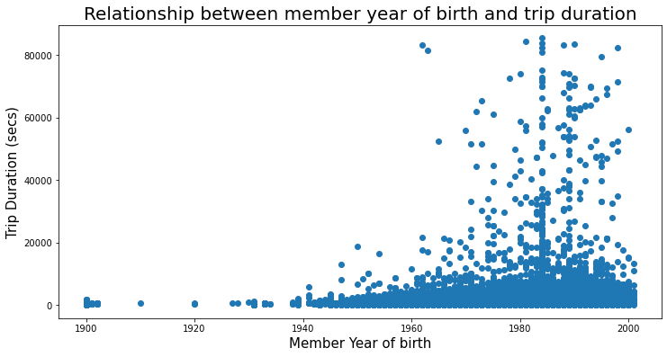

```python
# for the bivariate exploration, I want to to establish the relationship that exists between the numeric variables
# scatter plots
plt.figure(figsize = (12,6))

plt.scatter(data = go_bike,
            x = 'member_birth_year',
            y = 'duration_sec')
plt.xlabel('Member Year of birth', fontsize = 15)
plt.ylabel('Trip Duration (secs)', fontsize = 15)
plt.title('Relationship between member year of birth and trip duration', fontsize = 20)
plt.show()
```

The bike users who were born between 1970 and 2000 seemed to have significantly higher trip duration compared to those born earlier

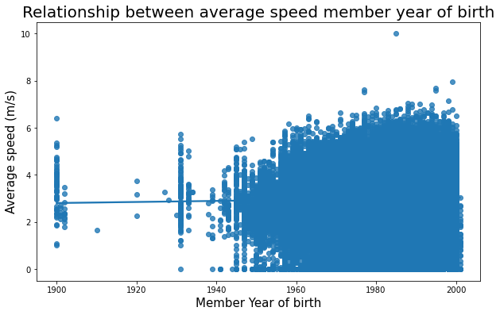

```python
# Scatter plot between year of birth and average speed
plt.figure(figsize = (10,6))

sns.regplot(data = go_bike,
            x = 'member_birth_year',
            y = 'avg_speed')
plt.xlabel('Member Year of birth', fontsize = 15)
plt.ylabel('Average speed (m/s)', fontsize = 15)
plt.title('Relationship between average speed member year of birth', fontsize = 20)
plt.show()
```

The average speed of the participants seemed to be slightly increasing for participants with the later years. Thats the younger, the participants the slightly the average speed increased.

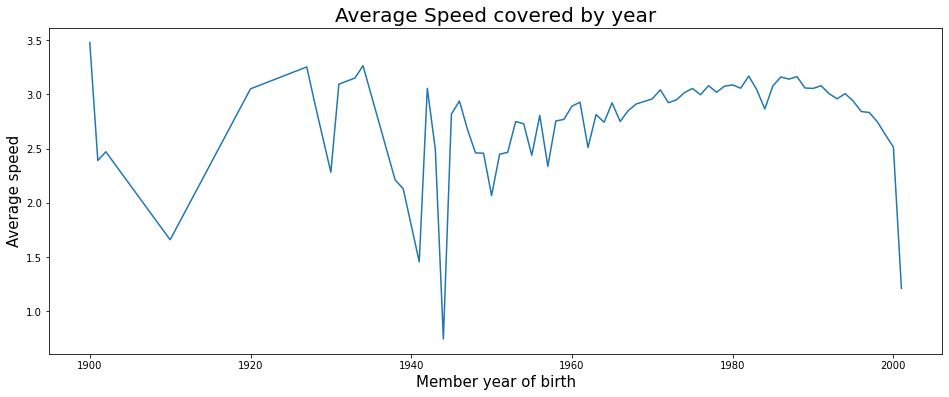

```python
time_speed = go_bike.groupby('member_birth_year')['avg_speed'].mean()

plt.figure(figsize = (16,6))

time_speed.plot()
plt.xlabel('Member year of birth', fontsize = 15)
plt.ylabel('Average speed', fontsize = 15)
plt.title('Average Speed covered by year', fontsize = 20)
plt.show()
```

### Average distance covered by year

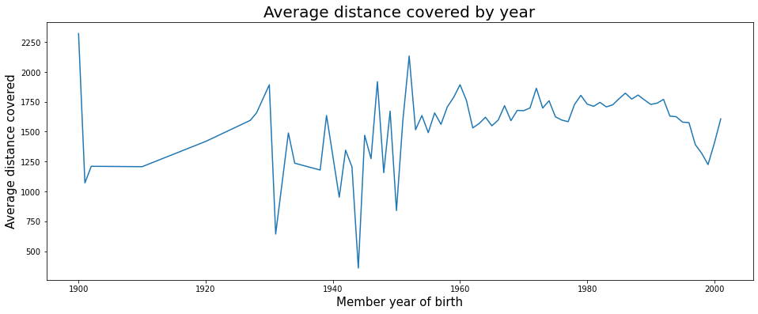

```python
time_distance = go_bike.groupby('member_birth_year')['distance_covered'].mean()

plt.figure(figsize = (16,6))

time_distance.plot()
plt.xlabel('Member year of birth', fontsize = 15)
plt.ylabel('Average distance covered', fontsize = 15)
plt.title('Average distance covered by year', fontsize = 20)
plt.show()
```

### Average speed v distance covered

Most users cycle on average speeds ranging from 2m/s to 4m/s

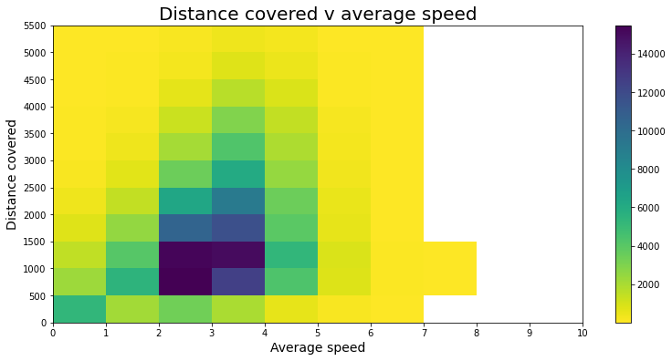

```python
plt.figure(figsize = (13,6))
#x bins 1m/s
bins_x = np.arange(0, go_bike['avg_speed'].max()+1, 1).astype(int)
#y bins 500m
bins_y = np.arange(0, go_bike['distance_covered'].quantile(0.99)+500, 500).astype(int)
plt.hist2d(data = go_bike,
           x = 'avg_speed',
           y = 'distance_covered',
          cmin = 0.5,
          cmap = 'viridis_r',
          bins= [bins_x, bins_y])
plt.colorbar()
plt.xlabel('Average speed', fontsize=14)
plt.ylabel('Distance covered', fontsize=14)
plt.xticks(bins_x)
plt.yticks(bins_y)
plt.title('Distance covered v average speed', fontsize=20)
plt.show()
```

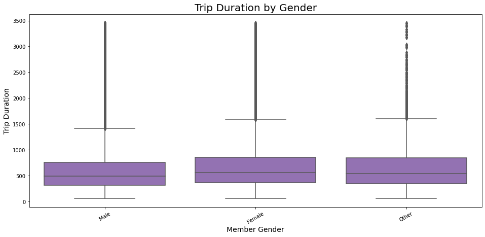

```python
# box pot for gender and distance covered
plt.figure(figsize = (16,7))

base_color = sns.color_palette()[4]
sns.boxplot(data = go_bike.query('duration_sec<duration_sec.quantile(0.99)'),
               x = 'member_gender',
               y = 'duration_sec',
              color = base_color);
plt.xlabel('Member Gender', fontsize=14)
plt.ylabel('Trip Duration', fontsize=14)
plt.title('Trip Duration by Gender', fontsize=20)
plt.xticks(rotation = 30);
```

- Average trip duration for all the gender seems to fall within a similar range

### User Count by bikeshare level and gender

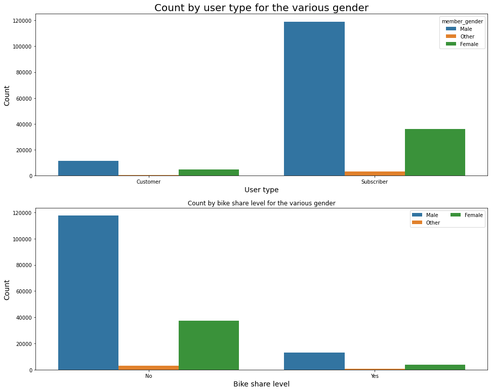

```python
# count by bikeshare level and gender
plt.figure(figsize = [16, 20])


plt.subplot(3, 1, 1)
sns.countplot(data = go_bike, x = 'user_type', hue = 'member_gender')
plt.xlabel('User type', fontsize=14)
plt.ylabel('Count', fontsize=14)
plt.title('Count by user type for the various gender', fontsize=20)


ax = plt.subplot(3, 1, 2)
sns.countplot(data = go_bike, x = 'bike_share_for_all_trip', hue = 'member_gender')
ax.legend(ncol = 2)
plt.xlabel('Bike share level', fontsize=14)
plt.ylabel('Count', fontsize=14)
plt.title('Count by bike share level for the various gender')

plt.show()
```

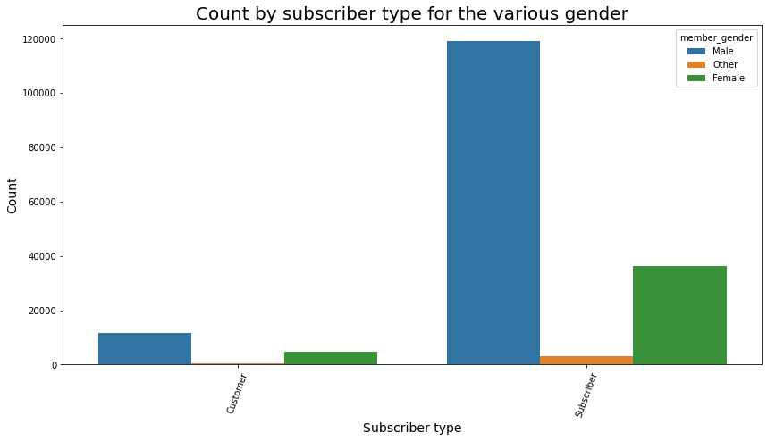

```python
plt.figure(figsize = (14,7))

sns.countplot(data = go_bike,
              x = 'user_type',
             hue = 'member_gender')
plt.xlabel('Member Gender')
plt.xticks(rotation = 70)
plt.xlabel('Subscriber type', fontsize=14)
plt.ylabel('Count', fontsize=14)
plt.title('Count by subscriber type for the various gender', fontsize=20);
```

- Most of the bike users are subscribers with, and men are significantly more than the female gender

```python
station_counts = go_bike['start_station_name'].value_counts()
station_counts.sort_values(ascending = False).head(10)
```

```
Market St at 10th St                                         3904
San Francisco Caltrain Station 2  (Townsend St at 4th St)    3544
Berry St at 4th St                                           3052
Montgomery St BART Station (Market St at 2nd St)             2895
Powell St BART Station (Market St at 4th St)                 2760
San Francisco Ferry Building (Harry Bridges Plaza)           2709
San Francisco Caltrain (Townsend St at 4th St)               2703
Powell St BART Station (Market St at 5th St)                 2327
Howard St at Beale St                                        2293
Steuart St at Market St                                      2283
Name: start_station_name, dtype: int64
```

# Multivariate Exploration

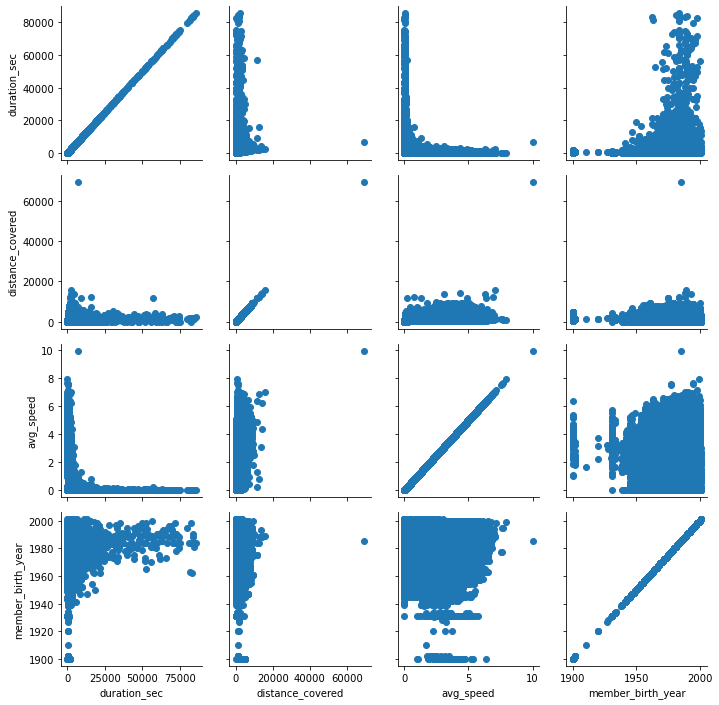

```python
numeric_bikes = ['duration_sec', 'distance_covered', 'avg_speed', 'member_birth_year']
g = sns.PairGrid(data = go_bike, vars = numeric_bikes)
g.map(plt.scatter);
```

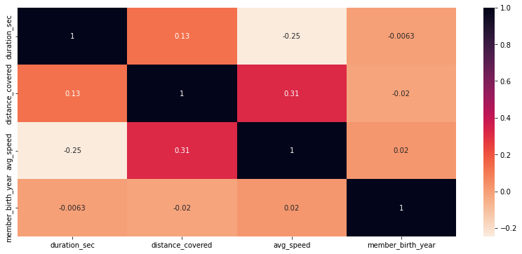

```python
## Heat map correlation

plt.figure(figsize = (16,10))

plt.figure(figsize=(14,6))
sns.heatmap(go_bike[numeric_bikes].corr(),
           cmap = 'rocket_r',
           annot = True);
```

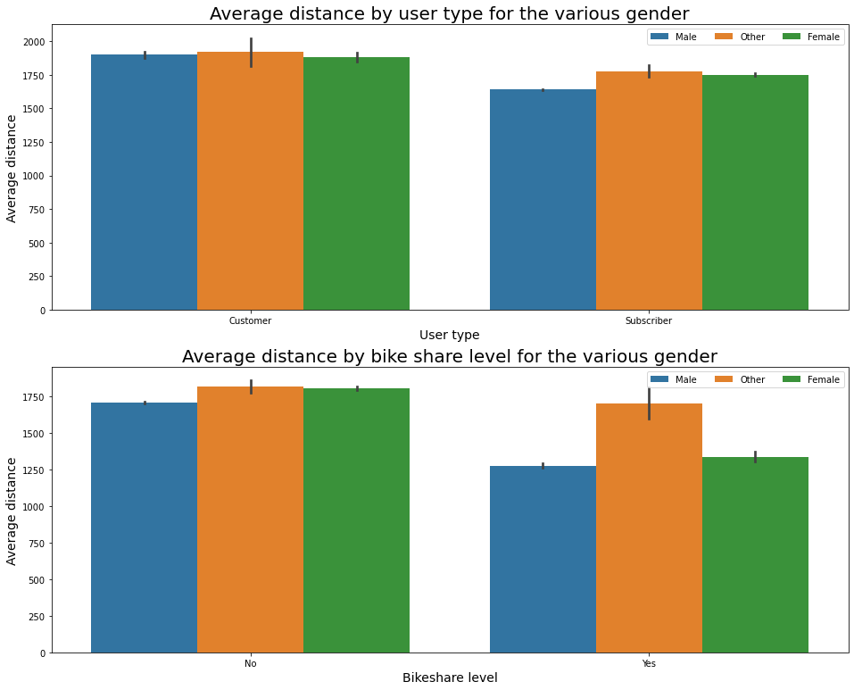

```python
# count by bikeshare level and gender
plt.figure(figsize=(16,20))

ax = plt.subplot(3,1,1)
sns.barplot(data = go_bike,
           x = 'user_type',
           y = 'distance_covered',
           hue = 'member_gender')
ax.legend(ncol=3)
plt.xlabel('User type', fontsize=14)
plt.ylabel('Average distance', fontsize=14)
plt.title('Average distance by user type for the various gender', fontsize=20)

ax = plt.subplot(3,1,2)
sns.barplot(data = go_bike,
           x = 'bike_share_for_all_trip',
           y = 'distance_covered',
           hue = 'member_gender')
ax.legend(ncol = 3)
plt.xlabel('Bikeshare level', fontsize=14)
plt.ylabel('Average distance', fontsize=14)
plt.title('Average distance by bike share level for the various gender', fontsize=20)

plt.show()
```

```python
!jupyter nbconvert Go_bike_Data_Part1.ipynb --to slides --post serve  --no-input --no-prompt
```